# mlproj

Cynthia Davies Cunha

Thursday, January 22, 2015

# Introduction

“Six young health participants were asked to perform one set of 10 repetitions of the Unilateral Dumbbell Biceps Curl in five different fashions: exactly according to the specification (Class A), throwing the elbows to the front (Class B), lifting the dumbbell only halfway (Class C), lowering the dumbbell only halfway (Class D) and throwing the hips to the front (Class E).

Class A corresponds to the specified execution of the exercise, while the other 4 classes correspond to common mistakes. Participants were supervised by an experienced weight lifter to make sure the execution complied to the manner they were supposed to simulate. The exercises were performed by six male participants aged between 20-28 years, with little weight lifting experience. We made sure that all participants could easily simulate the mistakes in a safe and controlled manner by using a relatively light dumbbell (1.25kg)." http://groupware.les.inf.puc-rio.br/har#weight_lifting_exercises

The training dataset used in the analysis is downloaded from “http://d396qusza40orc.cloudfront.net/predmachlearn/pml-training.csv” and the testing dataset from “http://d396qusza40orc.cloudfront.net/predmachlearn/pml-testing.csv”

The downloads result in ‘pml-training.csv’ and ‘pml-testing.csv’ dataset files, in a ‘Project 1’ directory created under the current working directory. Both are comma-separated-value (CSV) files and there are a total of 19,622 observations in the training set and 20 observations in the testing activity dataset.

Knitr was used to generate the report.

Original study data citation: “Velloso, E.; Bulling, A.; Gellersen, H.; Ugulino, W.; Fuks, H. Qualitative Activity Recognition of Weight Lifting Exercises. Proceedings of 4th International Conference in Cooperation with SIGCHI (Augmented Human ’13) . Stuttgart, Germany: ACM SIGCHI, 2013.”

We retrieve the datasets, training and testing, and report their dimensions.

```r
dim(training)
```

```
## [1] 19622   160
```

```r
dim(testing)
```

```
## [1]  20 160
```

## Exploring and Cleaning Data

We remove the calculated columns, those beginning with avg, min, max, kurtosis, amplitude and skewness and create a model using the raw positional data. We also delete columns with a preponderance of NAs, ~98% (19216/19622=0.9793089) because it makes no sense to impute from the remaining non-NA values. We then explore relationships between the remaining class variables.

```r
dim(training)
```

```
## [1] 19622    60
```

Exploration of the cvtd_timestamp class variable shows that study participants, adelmo and charles, performed barbell lifing on one date; carlitos and pedro, on another; and eurico and jeremy on still separate dates - none of which is important to the model. Thus, also, delete time-date classes from training.

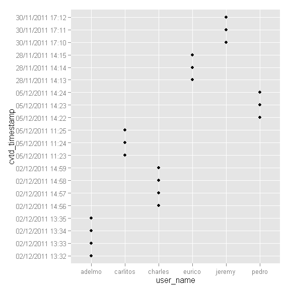

```r
qplot(user_name, cvtd_timestamp,data=training)
```

The final dimensions of the cleaned training data are:

```r
dim(training)
```

```
## [1] 19622    53
```

The final class names of the training data set to be used in the prediction model are:

```r
names(training)
```

```
##  [1] "roll_belt"            "pitch_belt"           "yaw_belt"
##  [4] "total_accel_belt"     "gyros_belt_x"         "gyros_belt_y"
##  [7] "gyros_belt_z"         "accel_belt_x"         "accel_belt_y"
## [10] "accel_belt_z"         "magnet_belt_x"        "magnet_belt_y"
## [13] "magnet_belt_z"        "roll_arm"             "pitch_arm"
## [16] "yaw_arm"              "total_accel_arm"      "gyros_arm_x"
## [19] "gyros_arm_y"          "gyros_arm_z"          "accel_arm_x"
## [22] "accel_arm_y"          "accel_arm_z"          "magnet_arm_x"
## [25] "magnet_arm_y"         "magnet_arm_z"         "roll_dumbbell"
## [28] "pitch_dumbbell"       "yaw_dumbbell"         "total_accel_dumbbell"
## [31] "gyros_dumbbell_x"     "gyros_dumbbell_y"     "gyros_dumbbell_z"
## [34] "accel_dumbbell_x"     "accel_dumbbell_y"     "accel_dumbbell_z"
## [37] "magnet_dumbbell_x"    "magnet_dumbbell_y"    "magnet_dumbbell_z"
## [40] "roll_forearm"         "pitch_forearm"        "yaw_forearm"
## [43] "total_accel_forearm"  "gyros_forearm_x"      "gyros_forearm_y"
## [46] "gyros_forearm_z"      "accel_forearm_x"      "accel_forearm_y"
## [49] "accel_forearm_z"      "magnet_forearm_x"     "magnet_forearm_y"
## [52] "magnet_forearm_z"     "classe"
```

The training data indicates that total arm acceleration may be related to increased chance of doing the barbell lift incorrectly (>50 seems to yield an error condition in the plot). A feature plot of acceleration does not show linearity.

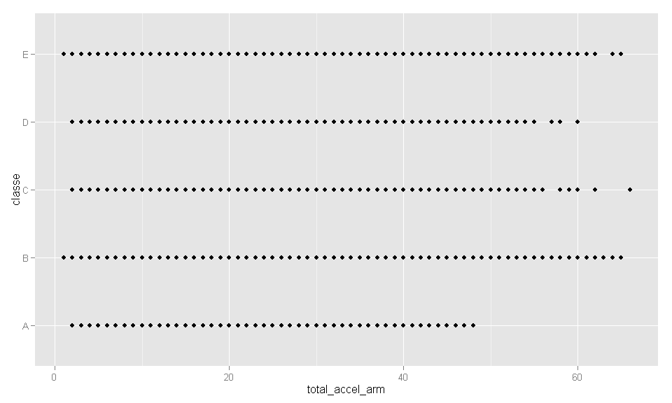

```r
qplot(total_accel_arm, classe, data=training)
```

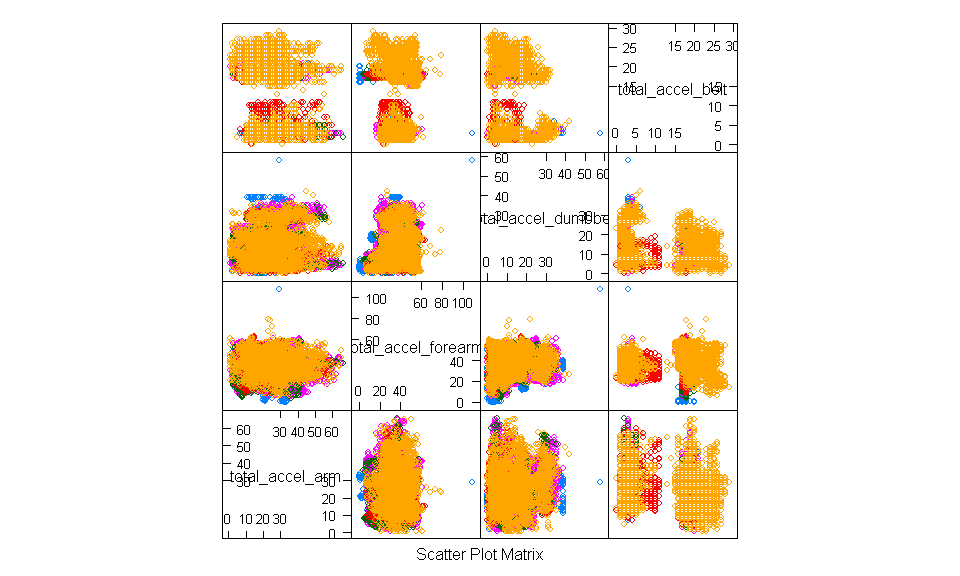

```r
featurePlot(x=training[, c("total_accel_arm","total_accel_forearm", "total_accel_dumbbell", "total_accel_belt")], y=training$classe, plot="pairs")
```

## Important class variables

> varImp(modFit, useModel=TRUE) rf variable importance

only 20 most important variables shown (out of 52)

[output not shown]

## Printing the exploratory model

> modFit Random Forest

19622 samples 52 predictor 5 classes: ‘A’, ‘B’, ‘C’, ‘D’, ‘E’

No pre-processing Resampling: Bootstrapped (25 reps)

Summary of sample sizes: 19622, 19622, 19622, 19622, 19622, 19622, …

Accuracy was used to select the optimal model using the largest value. The final value used for the model was mtry = 2.

## Create a final model

Based on the previous exploration the final model parameters are:

```r
modFit <- train(classe~., data=training, method="rf", tuneGrid=data.frame(mtry=2), trControl=trainControl(method="boot", number=25, repeats=25, p=0.75))
modFit
```

Random Forest

19622 samples 52 predictor 5 classes: ‘A’, ‘B’, ‘C’, ‘D’, ‘E’

No pre-processing Resampling: Bootstrapped (25 reps)

Summary of sample sizes: 19622, 19622, 19622, 19622, 19622, 19622, …

Resampling results

Accuracy Kappa Accuracy SD Kappa SD  
0.9925818 0.9906161 0.001360861 0.001719946

Tuning parameter ‘mtry’ was held constant at a value of 2

```r
answer <- predict(modFit, newdata=testing)
```

# Supplementary details - system environment and software version

```r
# This report is generated under the following system.
print(sessionInfo()$R.version$version.string)
```

```
## [1] "R version 3.1.2 (2014-10-31)"
```

```r
# It also uses the following packages:
citation("rstudio")
```

```
##
##
##   RStudio Team (2012). RStudio: Integrated Development for R.
##   RStudio, Inc., Boston, MA URL http://www.rstudio.com/.
##
## A BibTeX entry for LaTeX users is
##
##   @Manual{,
##     title = {RStudio: Integrated Development Environment for R},
##     author = {{RStudio Team}},
##     organization = {RStudio, Inc.},
##     address = {Boston, MA},
##     year = {2012},
##     url = {http://www.rstudio.com/},
##   }
```

```r
citation("caret")
```

```
##
##
##   Max Kuhn. Contributions from Jed Wing, Steve Weston, Andre
##   Williams, Chris Keefer, Allan Engelhardt, Tony Cooper, Zachary
##   Mayer, Brenton Kenkel, the R Core Team, Michael Benesty, Reynald
##   Lescarbeau, Andrew Ziem and Luca Scrucca. (2015). caret:
##   Classification and Regression Training. R package version
##   6.0-41. http://CRAN.R-project.org/package=caret
##
## A BibTeX entry for LaTeX users is
##
##   @Manual{,
##     title = {caret: Classification and Regression Training},
##     author = {Max Kuhn. Contributions from Jed Wing and Steve Weston and Andre Williams and Chris Keefer and Allan Engelhardt and Tony Cooper and Zachary Mayer and Brenton Kenkel and the R Core Team and Michael Benesty and Reynald Lescarbeau and Andrew Ziem and Luca Scrucca.},
##     year = {2015},
##     note = {R package version 6.0-41},
##     url = {http://CRAN.R-project.org/package=caret},
##   }
##
## ATTENTION: This citation information has been auto-generated from
## the package DESCRIPTION file and may need manual editing, see
## 'help("citation")'.
```